# Mid-term Exam #2

Due date: 6 November

Please read all of the questions carefully and follow all instructions. Each question has an allotted point value. Be as thorough and specific as possible; extra calculations and incorrect information, even in the presence of correct information, will result in point deductions. Be sure to show all formulas and all necessary work to answer the questions. You may upload your completed exam to the Elms course site (attach to Midterm Exam #2).

**Note**

While this is an open-note exam, you are not to receive assistance from anyone else (as usual, the Honor Code applies).

```r
library(tidyverse)
library(modelsummary)
library(infer)
library(poliscidata)
```

**Total points: 50 points**

## Conceptual questions

**Note**

Please include all work (and computations) necessary to answer the questions.

**Total points: 26**

### Question 1

*2 points*

**Suppose I am interested in determining if freshman undergraduates at the University of Maryland spend more hours studying in the average week than sophomore undergraduates. I conduct a study in which I take a simple random sample (SRS) of 1200 freshman students and 1200 sophomore students. I find that the freshman students in my sample study for, on average, 412 minutes per week and the sophomore students in my sample study for, on average, 335 minutes per week. The standard error of the difference is 30. What is a 90% confidence interval for the difference between freshman and sophomore students?**

90% confidence interval z= 1.645

$\left(412-335\right)+1.645\left(30\right)$ = 126.35

$\left(412-335\right)-1.645\left(30\right)$ = 27.65

The 90% confidence interval for the difference between freshman and sophomore students is [27.65, 126.35].

### Question 2

*2 points*

**Based on the results of my study described in question 1, can you reject the null hypothesis of no statistically meaningful difference in the study habits of sophomore and freshman students? Why or why not?**

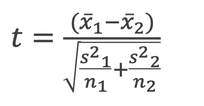

t = $\frac{\left(412-335\right)}{30}$ = 2.566666667

.9948 | 1-.9948=.0052

Based on the results of the study, you can the reject the null hypothesis of no statistically meaningful difference in the study habits of sophomore and freshman students because the p-value is less than 0.05. Specifically, the p-value associated with the test statistic (2.56) is .0052 suggests that there is a .52% chance that you would have pulled such a sample from the population if the null hypothesis were true.

### Question 3

*2 points*

**If I am testing a null hypothesis that X has no effect on Y in the population (and thus my alternative hypothesis is that X does have an effect), why might I prefer to commit a Type-II error over a Type-I error (and, of course, this holds aside my first preference of making no error at all)? Answer in no more than two sentences.**

If testing a null hypothesis, you might prefer to commit a Type-II error over a Type-I error, as committing a Type-I error, or stating that there is a relationship between variables based on the sample when in actuality there is no relationship in the population has the potential to mislead research. Conversely, in academia, researchers would prefer to commit a Type-II error and say that based on a sample, there is no relationship even if in actuality in the population there is a relationship between variables as even if a relationship exists in the population such a relationship could be hard to find and parse out for a multitude of reasons such as difficulty of gathering data or forming a large enough sample size.

### Question 4

*1 point*

**When conducting a difference-of-means test, which of the following samples would yield a sampling distribution with the lowest variability?**

1. **A sample of 900 with a standard deviation of 15**
2. A sample of 25 with a standard deviation of 10
3. A sample of 625 with a standard deviation of 20
4. A sample of 100 with a standard deviation of 6

### Question 5

*1 point*

**Which of the following probabilities is not independent?**

1. The probability that the roulette wheel will end up on 23 two times in a row.
2. The probability that three successive coin tosses will each turn up heads.
3. **The probability that I draw an ace and then a king in a row from a deck of cards (when drawing a two-card hand).**
4. The probability that I will get a 6 on three subsequent die rolls.
5. None of the above – all are independent probabilities.

### Question 6

*1 point*

**I conduct a two-tailed difference-of-means test and obtain a t-statistic of 2.10. Is my result statistically significant (with 95% confidence)?**

[p = 0.9821] or .0179 (1-0.9821) | .0179*2 = 0.0358

1. **Yes, at the 0.05 level (p<0.05)**
2. Yes, but only at the 0.10 level (p<0.10)
3. Not at either the 0.05 or the 0.10 level
4. There is not enough information to answer this question.

### Question 7

*1 point*

**I take a sample of 1800 adults and find that 360 of them watched last Monday’s NFL game. What probability represents the complement to the sample proportion of adults who watched the NFL game?**

P(Complement)=1-P(A)

P(A) = 360/1800 = 0.2

Complement = 1-(360/1800) = .8

The probability, 0.8 or 80%, represents the complement to the sample proportion of adults who watched the NFL game.

### Question 8

*1 point*

**Which of the following makes it more likely that a given sample statistic will be statistically different from zero (and thus allow you to reject the null hypothesis, all else equal)?**

1. **More observations**
2. Greater variance in the sample
3. Using a two-tailed instead of a one-tailed significance test
4. A larger confidence interval around the test statistic
5. Both (a) and (b) (but not (c) or (d))
6. All of the above increase the chances of statistical significance
7. None of the above

### Question 9

*1 point*

**The p-value for a two-tailed test of the null hypothesis** $H_0: \mu=40$ **is 0.06. Which of the following statements is accurate?**

1. A 95% confidence interval around the sample mean includes the value 40
2. **A 90% confidence interval around the sample mean includes the value 40**
3. A 99% confidence interval around the sample mean does not include the value 40
4. None of the above statements are correct
5. All of the above statements are correct

### Question 10

*4 points total*

#### Part A

*2 points*

**If you roll a fair (six-sided) die twice, what is the probability that both rolls will be odd or greater than four?**

P(A & B)=P(A)*P(B)

[1,2,3,4,5,6]

P(A) = odd (1,3,5) or >4 (5,6) [1,3,5,6] = 4/6

P(B) = odd (1,3,5) or >4 (5,6) [1,3,5,6] = 4/6

$\frac{4}{6}*\frac{4}{6}$ = 0.4444444444

If you roll a fair six-sided die twice, the probability that both rolls will be odd or greater than four is 0.4444 or 44.44%.

#### Part B

*2 points*

The following is a distribution of U.S. college students classified by their age and full- vs. part-time status. Based on these data, what is the probability that a student is in the 25-29 age group, given that (i.e., conditional on knowledge that) the student is full time?

```r
tibble::tibble(
  age = c("15 - 19", "20 - 24", "25 - 29", "30+"),
  full_time = c(155, 255, 75, 35),
  part_time = c(20, 55, 80, 95)
) |>
  knitr::kable()
```

| age | full_time | part_time |
| --- | --- | --- |
| 15 - 19 | 155 | 20 |
| 20 - 24 | 255 | 55 |
| 25 - 29 | 75 | 80 |
| 30+ | 35 | 95 |

155+255+75+35=520

155+255+75+35+20+55+80+95=770

P(A|B)=P(A and B)/P(B)

P(A and B)= probability 25-29 and full time = 75/770 = 0.0974025974

P(B) = probability full time = $\frac{520}{770}$ = 0.6753246753

$\frac{0.0974025974}{0.6753246753}$ = 0.1442307692

The probability that a student is in the 25-29 age group, given that (i.e., conditional on knowledge that) the student is full time is 0.1442307692 or 14.423%.

### Question 11

*4 points total*

#### Part A

*2 points*

Using a SRS of 1211 people, I estimate that the proportion of people living in the South that favor teaching sexual education in public schools is 0.874 and the proportion of people outside of the south that favor teaching sexual education in public schools is 0.906. And, the standard error of the difference (in citizen views about teaching sexual education in public schools) between people living in the south and those not living in the south is 0.015. Give an interval estimate for the difference in the proportion of people favoring sex education in public schools between people who do, and do not, live in the south.

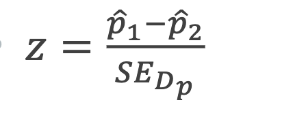

z = $\frac{\left(.906-.874\right)}{.015}$ = 2.133333333

m = $2.133333333\cdot0.015$ = 0.032

D = .906-.874 = 0.032

$\left(.906-.874\right)+2.133333333\cdot\sqrt{\frac{.906\left(1-.906\right)}{1211}+\frac{.874\left(1-.874\right)}{1211}}$ = 0.05909096196

$\left(.906-.874\right)-2.133333333\cdot\sqrt{\frac{.906\left(1-.906\right)}{1211}+\frac{.874\left(1-.874\right)}{1211}}$ = 0.004909038039

An interval estimate for the difference in the proportion of people favoring sex education in public schools between people who do, and do not, live in the south is [0.004909038039, 0.05909096196].

#### Part B

*2 points*

**Do the data (i.e., estimates above) show support for my hypothesis? How do you know?**

### Question 12

*6 points total*

**I am interested in estimating the average number of texts that University of Maryland undergraduate students send in a day. My hypothesis is that the average number of texts students send is greater than 100. I take a SRS of 1600 students and find that the mean number of texts they send is 105, and with a standard deviation of 120.**

#### Part A

*2 points*

What is a 95% confidence interval around the sample statistic?

95% confidence interval equation = $\bar{x} \pm z \cdot (s\div \sqrt{n})$

$$\bar{x} = 105,
n = 1600,
s = 120,
z = 1.96$$

$$105+1.96\left(\frac{120}{\sqrt{1600}}\right) = 110.88$$

The 95% confidence interval around that estimate is (99.12, 110.88).

#### Part B

*2 points*

**When testing the null hypothesis, what is the test statistic associated with the sample statistic?**

$\frac{\left(105-100\right)}{\frac{120}{\sqrt{1600}}}$ = 1.666666667

When testing the null hypothesis, the test statistic associated with the sample statistic is 1.666666667.

#### Part C

*2 points*

**If using a one-tailed test of the null hypothesis and you are willing to accept a Type-I error rate of 0.05, do the data support my hypothesis? Why or why not?**

If using a one-tailed test of the null hypothesis and you are willing to accept a Type-I error rate of 0.05, the data does support your hypothesis because the p-value is less than 0.05. Specifically, the p-value associated with the above test statistic is .0475.

## Applied questions

**Note**

All datasets referenced below are available through the course elms page. Do note use the `poliscidata` package for these questions, as the specific variables referenced are not all included in that package.

**Total points: 24**

### Question 1

*8 points total*

I hypothesize that, among only those that were eligible to vote, people with greater confidence in the U.S. military were more likely to turnout to vote in the 2008 presidential election. Use data from the General Social Survey (i.e., the `gss` dataset) to test my hypothesis (the unit of analysis is the individual survey respondent). Specifically, use the following variables: `conarmy` (1 = a “great deal” of confidence; 2 = “only some” confidence; 3 = “hardly any”); and `vote08` (1 = did not vote; 2 = voted). Answer the following questions.

#### Part A

*3 points*

Complete a cross-tab and interpret the results. Do the data support my hypothesis? Be sure to explain the nature of the relationship (or lack thereof, if relevant).

```r
gss <- gss |>
    mutate(conarmy = factor(conarmy,
                            levels = c("A GREAT DEAL", "ONLY SOME", "HARDLY ANY")),
           voted08 = factor(voted08, levels = c("Did not vote", "Voted")))
datasummary_crosstab(voted08 ~ conarmy,
                     statistic = 1 ~ 1 + N + Percent ("col"),
                     data = gss)
```

| voted08 |  | A GREAT DEAL | ONLY SOME | HARDLY ANY | All |
| --- | --- | --- | --- | --- | --- |
| Did not vote | N | 173 | 108 | 35 | 485 |
|  | % col | 23.8 | 22.4 | 32.1 | 24.6 |
| Voted | N | 497 | 327 | 60 | 1304 |
|  | % col | 68.5 | 67.8 | 55.0 | 66.1 |
| All | N | 726 | 482 | 109 | 1974 |
|  | % col | 100.0 | 100.0 | 100.0 | 100.0 |

The data does support your hypothesis. In the 2008 presidential election, those with greater confidence in the military made up a greater share of the proportion of those who voted compared to those who did not have high confidence in the military. Specifically, 68.5% of those with a great deal of confidence in the military voted, compared to 55.0% of who had hardly any confidence in the military who voted.

Similarly, those with lower levels of confidence in the military make up a greater proportion of those who did not vote in the 2008 election. Specifically, 32.1% of those with hardly any confidence in the military did not vote compared to 23.8% of those with a great deal of confidence in the military who did not vote in the 2008 presidential election. However, the relationship is not perfect as 22.4% of those with only some confidence in the military did not vote, a smaller proportion than those with a great deal or more confidence in the military who did not vote.

#### Part B

*3 points*

**Compute (by hand) the chi-square statistic to test the null hypothesis of no relationship between these two variables. Be sure to show your work.**

```r
obs_values <- count(gss, voted08, conarmy, name = "obs_n")
conarmy_totals <- count(gss, conarmy, name = "conarmy_total")
voted08_totals <- count(gss, voted08, name = "voted08_total")

obs_exp_counts <- voted08_totals |>
    expand_grid(conarmy_totals) |>
    relocate(conarmy) |>
    mutate(exp_n = (voted08_total * conarmy_total) / nrow(gss)) |>
    left_join(obs_values, by = c("conarmy", "voted08"))

obs_exp_counts
```

```
# A tibble: 12 × 6
   conarmy      voted08      voted08_total conarmy_total exp_n obs_n
   <fct>        <fct>                <int>         <int> <dbl> <int>
 1 A GREAT DEAL Did not vote           485           726 178.    173
 2 ONLY SOME    Did not vote           485           482 118.    108
 3 HARDLY ANY   Did not vote           485           109  26.8    35
 4 <NA>         Did not vote           485           657 161.    169
 5 A GREAT DEAL Voted                 1304           726 480.    497
 6 ONLY SOME    Voted                 1304           482 318.    327
 7 HARDLY ANY   Voted                 1304           109  72.0    60
 8 <NA>         Voted                 1304           657 434.    420
 9 A GREAT DEAL <NA>                   185           726  68.0    56
10 ONLY SOME    <NA>                   185           482  45.2    47
11 HARDLY ANY   <NA>                   185           109  10.2    14
12 <NA>         <NA>                   185           657  61.6    68
```

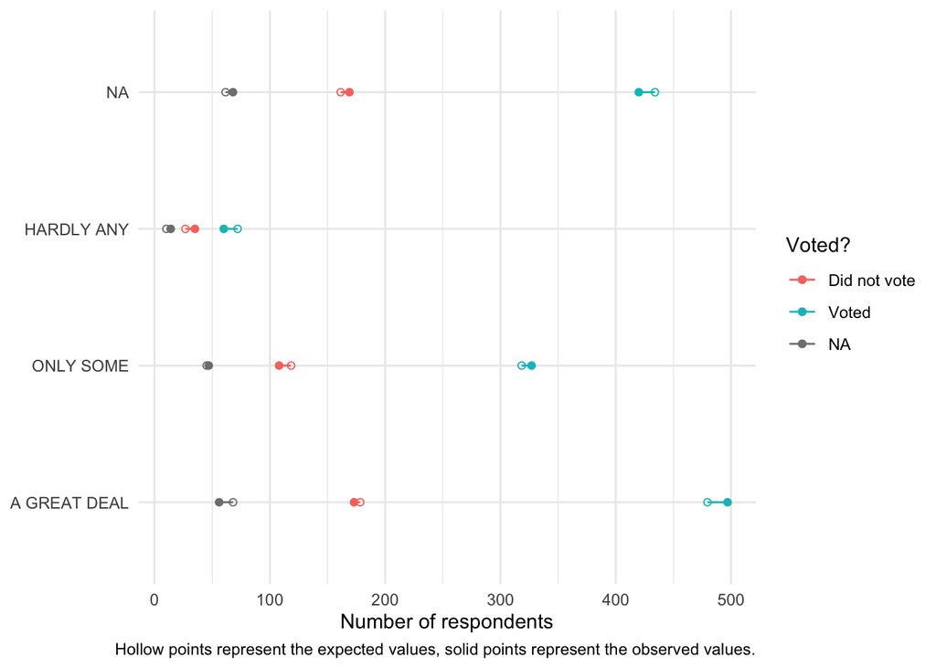

```r
ggplot(obs_exp_counts, aes(y = conarmy, colour = voted08)) +
    geom_segment(aes(x = exp_n, xend = obs_n, yend = conarmy)) +
    geom_point(aes(x = exp_n), shape = 1) +
    geom_point(aes(x = obs_n)) +
    labs(x = "Number of respondents",
         y = NULL,
         colour = "Voted?",
         caption = "Hollow points represent the expected values, solid points represent the observed values.") +
    theme_minimal()
```

```r
chi_sq <- obs_exp_counts |>
    mutate(diff = obs_n - exp_n,
           diff_2 = diff^2,
           diff_2_standard = diff_2 / exp_n) |>
    summarise(chi_sq = sum(diff_2_standard)) |>
    pull()

chi_sq
```

```
[1] 11.55303
```

```r
pchisq(chi_sq, df = 2, lower.tail = F)
```

```
[1] 0.003099498
```

The chi-square statistic is 11.55303.

#### Part C

*2 points*

**Using the chi-square statistic that you computed in question 1(b), can you reject the null hypothesis of no relationship between these two variables with 95% confidence? Why, or why not?**

Using the chi-square statistic that I computed in question 1(b), I can reject the null hypothesis of no relationship of no relationship between these two variables with 95% confidence because the p-value associated with the chi-square statistic (11.55303) is less than 0.05, the commonly-used metric for social science research. Specifically, the p-value is 0.003099498. Thus, that means that there is a 0.30994% chance that one would have pulled a sample from the population with the differences present between the two groups if the null hypothesis were true.

### Question 2

*8 points total*

**I hypothesize that citizens who do not support fracking are less conservative than those who do support fracking. Use data from the `nes` dataset to test my hypothesis (the unit of analysis is the individual survey respondent). Specifically, use the following variables: `fracking` (1 = “approve” of fracking; 2 = “middle”; 3 = “disapprove”); and `libcon7` (higher values represent less liberalism, or more conservatism). Answer the following questions.**

#### Part A

*2 points*

**Using these data, what is the point estimate for the mean conservatism/liberalism score among those that disapprove of fracking? What is the point estimate for the mean conservatism/liberalism score among those that approve of fracking?**

```r
compmeans(nes$pid_x, nes$envir_drill, nes$wt, plot=F)
```

```
Mean value of "nes$pid_x" according to "nes$envir_drill"
                                Mean    N Std. Dev.
1. Favor                    4.465994 3155  2.103410
2. Oppose                   2.819144 1022  1.769025
3. Neither favor nor oppose 3.189964 1630  1.830119
Total                       3.817994 5807  2.099538
```

Using these data, the point estimate for the mean conservatism/liberalism score among those that disapprove of fracking is 2.819144. The point estimate for the mean conservatism/liberalism score for those that approve of fracking is 4.465994.

#### Part B

*6 points*

**Evaluate the null hypothesis that there is no difference in the mean conservatism/liberalism score among those that approve vs. disapprove of fracking. Do the data support my hypothesis? Why or why not? Be sure to show all work necessary to answer the question by hand (i.e., you may only use R to the extent that is absolutely necessary to complete the question; otherwise, you must show how you would answer the question by hand).**

```r
datasummary_crosstab(envir_drill ~ pid_x, data = nes,
                     statistic = 1 ~ 1 + N + Percent("col"))
```

| envir_drill |  | StrDem | WkDem | IndDem | Ind | IndRep | WkRep | StrRep | All |
| --- | --- | --- | --- | --- | --- | --- | --- | --- | --- |
| 1. Favor | N | 581 | 327 | 295 | 331 | 467 | 428 | 640 | 3080 |
|  | % col | 39.1 | 37.5 | 39.5 | 41.8 | 76.6 | 68.7 | 84.0 | 52.1 |
| 2. Oppose | N | 369 | 205 | 209 | 135 | 44 | 57 | 41 | 1063 |
|  | % col | 24.8 | 23.5 | 28.0 | 17.0 | 7.2 | 9.1 | 5.4 | 18.0 |
| 3. Neither favor nor oppose | N | 493 | 326 | 228 | 293 | 97 | 132 | 79 | 1652 |
|  | % col | 33.2 | 37.3 | 30.5 | 37.0 | 15.9 | 21.2 | 10.4 | 27.9 |
| All | N | 1485 | 873 | 747 | 792 | 610 | 623 | 762 | 5916 |
|  | % col | 100.0 | 100.0 | 100.0 | 100.0 | 100.0 | 100.0 | 100.0 | 100.0 |

The data does support your hypothesis that citizens who do not support fracking are less conservative than those who do support fracking. Specfically, 84% of those who identify as strongly Republican are in favor of fracking compared to only 39% of strong Democrats.

Furthermore, 24.8% of strong Democrats oppose fracking compared to 5.4% of strong Republicans. Lastly, conservatives were less likely to respond that they neither favor nor oppose fracking compared to strong democrats and independents.

The difference in the mean approval and disapproval of fracking between conservatives and liberals is statistically significant as the p-value associated with the chi-square statistic of 907.7343 is less than 1.253933e-186. Thus, that means that there is a close to 0% chance that one would have pulled a sample that demonstrated a difference in support for fracking based on party identification if the null hypothesis were true. Thus, one can reject the null hypothesis.

```r
obs_values <- count(nes, envir_drill, pid_x, name = "obs_n")
pid_x_totals <- count(nes, pid_x, name = "pid_x_total")
envir_drill_totals <- count(nes, envir_drill, name = "envir_drill_total")

obs_exp_counts <- envir_drill_totals |>
    expand_grid(pid_x_totals) |>
    relocate(pid_x) |>
   mutate(exp_n = (envir_drill_total * pid_x_total) / nrow(nes)) |>
    left_join(obs_values, by = c("pid_x", "envir_drill"))

obs_exp_counts
```

```
# A tibble: 32 × 6
   pid_x  envir_drill envir_drill_total pid_x_total exp_n obs_n
   <fct>  <fct>                   <int>       <int> <dbl> <int>
 1 StrDem 1. Favor                 3080        1485 773.    581
 2 WkDem  1. Favor                 3080         873 455.    327
 3 IndDem 1. Favor                 3080         747 389.    295
 4 Ind    1. Favor                 3080         792 412.    331
 5 IndRep 1. Favor                 3080         610 318.    467
 6 WkRep  1. Favor                 3080         623 324.    428
 7 StrRep 1. Favor                 3080         762 397.    640
 8 <NA>   1. Favor                 3080          24  12.5    11
 9 StrDem 2. Oppose                1063        1485 267.    369
10 WkDem  2. Oppose                1063         873 157.    205
# ℹ 22 more rows
```

```r
chi_sq <- obs_exp_counts |>
    mutate(diff = obs_n - exp_n,
           diff_2 = diff^2,
           diff_2_standard = diff_2 / exp_n) |>
    summarise(chi_sq = sum(diff_2_standard)) |>
    pull()

chi_sq
```

```
[1] 907.7343
```

```r
pchisq(chi_sq, df = 12, lower.tail = F)
```

```
[1] 1.253933e-186
```

### Question 3

*8 points total*

**I hypothesize that people who express that religion is important to them were more likely to turnout to vote in the 2008 presidential election. Use data from the `nes` dataset to test my hypothesis (the unit of analysis is the individual survey respondent). Specifically, use the following variables: `relig_pray`, which describes how often the respondent prays (1 = several times a day; 2 = once a day; 3 = a few times a week; 4 = once a week or less; 5 = never); and `voted2008` (1 = did not vote; 2= voted). Answer the following questions.**

#### Part A

*2 points*

**Using these data, what is the point estimate for the proportion of respondents that voted (i.e., turnout rate), among citizens expressing that religion is not important? What is the point estimate for the proportion of respondents that voted, among citizens expressing that religion matters a great deal?**

```r
xtabC(~voted2008 + relig_pray, nesD)
```

```
         relig_pray
voted2008 01. Several times a day 02. Once a day 03. A few times a week
    No                      19.86          23.13                  25.09
    Yes                     80.14          76.87                  74.91
    Total                  100.00         100.00                 100.00
    Count                 1636.92        1037.46                1096.39
         relig_pray
voted2008 04. Once a week or less 05. Never 95. Other {VOL} {SPECIFY}
    No                      27.41     29.90                       NaN
    Yes                     72.59     70.10                       NaN
    Total                  100.00    100.00                       NaN
    Count                  993.18   1090.91                         0
```

The point estimate for the proportion of respondents that voted (i.e., turnout rate), among citizens expressing that religion is not important is 70.10.

The point estimate for the proportion of respondents that voted, among citizens expressing that religion matters a great deal is 80.14.

#### Part B

*6 points*

**Evaluate the null hypothesis that there is no difference in the proportion of voters (i.e., turnout rate) among citizens expressing that religion is not important vs. those reporting that religion matters a great deal. Do the data support my hypothesis? Why or why not? Be sure to show all work necessary to answer the question by hand (i.e., you may only use R to the extent that is absolutely necessary to complete the question; otherwise, you must show how you would answer the question by hand).**

```r
nes <- nes |>
    mutate(relig_pray = factor(relig_pray,
                               levels = c("01. Several times a day", "02. Once a day", "03. A few times a week", "04. Once a week or less", "05. Never")),
           voted2008 = factor(voted2008, levels = c("No", "Yes")))
datasummary_crosstab(voted2008 ~ relig_pray, data = nes,
                     statistic = 1 ~ 1 + N + Percent("col"))
```

| voted2008 |  | 01. Several times a day | 02. Once a day | 03. A few times a week | 04. Once a week or less | 05. Never | All |
| --- | --- | --- | --- | --- | --- | --- | --- |
| No | N | 308 | 240 | 243 | 245 | 262 | 1309 |
|  | % col | 17.5 | 22.0 | 22.5 | 24.8 | 27.4 | 22.1 |
| Yes | N | 1445 | 849 | 835 | 741 | 687 | 4585 |
|  | % col | 82.1 | 77.7 | 77.4 | 75.0 | 71.9 | 77.5 |
| All | N | 1761 | 1093 | 1079 | 988 | 955 | 5916 |
|  | % col | 100.0 | 100.0 | 100.0 | 100.0 | 100.0 | 100.0 |

Though, overall, the majority of respondents voted, there is a difference between the proportion of voters who voted who expressed religion is not important vs those reporting religion matters a great deal. Specifically, 82.1% of those pray several times a day voted compared to 71.9% of those who never pray. Furthermore, 17.5% of those who pray several times a day did not vote compared to %27.4% of those who never pray.

The difference in the mean turnout among those who expressed different views on the importance of religion is statistically significant as the p-value is less than 0.05. Specifically, the chi-square statistic (41.959) is associated with a p-value less than 1.701e-08. This means that there is a close to 0% chance that one would have pulled such a sample with different levels of turnout based on the importance of religion in their lives if the null hypothesis were true.

```r
obs_values <- count(nes, voted2008, relig_pray, name = "obs_n")

relig_pray_totals <- count(nes, relig_pray, name = "relig_pray_total")
voted2008_totals <- count(nes, voted2008, name = "voted2008_total")

obs_exp_counts <- voted2008_totals |>
    expand_grid(relig_pray_totals) |>
    relocate(relig_pray) |>
    mutate(exp_n = (voted2008 * relig_pray_total) / nrow(nes)) |>
    left_join(obs_values, by = c("relig_pray", "voted2008"))

obs_exp_counts
```

```
# A tibble: 18 × 6
   relig_pray             voted2008 voted2008_total relig_pray_total exp_n obs_n
   <fct>                  <fct>               <int>            <int> <dbl> <int>
 1 01. Several times a d… No                   1309             1761    NA   308
 2 02. Once a day         No                   1309             1093    NA   240
 3 03. A few times a week No                   1309             1079    NA   243
 4 04. Once a week or le… No                   1309              988    NA   245
 5 05. Never              No                   1309              955    NA   262
 6 <NA>                   No                   1309               40    NA    11
 7 01. Several times a d… Yes                  4585             1761    NA  1445
 8 02. Once a day         Yes                  4585             1093    NA   849
 9 03. A few times a week Yes                  4585             1079    NA   835
10 04. Once a week or le… Yes                  4585              988    NA   741
11 05. Never              Yes                  4585              955    NA   687
12 <NA>                   Yes                  4585               40    NA    28
13 01. Several times a d… <NA>                   22             1761    NA     8
14 02. Once a day         <NA>                   22             1093    NA     4
15 03. A few times a week <NA>                   22             1079    NA     1
16 04. Once a week or le… <NA>                   22              988    NA     2
17 05. Never              <NA>                   22              955    NA     6
18 <NA>                   <NA>                   22               40    NA     1
```

```r
chi_sq <- obs_exp_counts |>
    mutate(diff = obs_n - exp_n,
           diff_2 = diff^2,
           diff_2_standard = diff_2 / exp_n) |>
    summarise(chi_sq = sum(diff_2_standard)) |>
    pull()

chi_sq
```

```
[1] NA
```

```r
pchisq(chi_sq, df = 4, lower.tail = F)
```

```
[1] NA
```

```r
chisq.test(nes$voted2008, nes$relig_pray)
```

```
    Pearson's Chi-squared test

data:  nes$voted2008 and nes$relig_pray
X-squared = 41.959, df = 4, p-value = 1.701e-08
```